# Case Study 01

Katherine Lockard, Eli Kravez

## Introduction

In this case study, we will analyze beers and breweries in the US. We worked with two data sets. One dataset contained 2410 different beers, and the other contained 558 breweries in the United States. Later, we will analyze alcohol content and bitterness for these beers, determine if they are related, and if there are trends in certain states.

First, make sure required libraries are installed. Some important ones we used are: e1071 for Naive Bayes, ggplot2 for visualization, usmap to create the us map, caret & class were used for kNN, and visdat to visualize missing values. If an error is given, try installing tinytex using the comment below.

```r
  packages <- c("ggplot2", "visdat", "leaps", "ggcorrplot", "leaps", "plotrix", "e1071")

  #Tinytex installation, if error arises
  #tinytex::install_tinytex()

  # Install packages not yet installed
  installed_packages <- packages %in% rownames(installed.packages())
  if (any(installed_packages == FALSE)) {
    install.packages(packages[!installed_packages])
  }

  library(ggcorrplot)
  library(visdat)
  library(dplyr)
  library(tidyverse)
  library(plyr)
  library(leaps)
  library(zoo)
  library(ggplot2)
  library(GGally)
  library(plotrix)
  library(usmap)
  library(ggthemes)
  library(caret)
  library(class)
  library(e1071)
```

## Read Data

Read data from Beers and Breweries data sets. Make sure to update the file path before running this code.

```r
Beers <- read.csv("/Users/katherinelockard/Documents/SMU/Doing Data Science/Case Study 1/Beers.csv", header=T, na.strings=c("","NA"))
Breweries <- read.csv("/Users/katherinelockard/Documents/SMU/Doing Data Science/Case Study 1/Breweries.csv", header=T, na.strings=c("","NA"))
```

## Question 1: How many breweries are present in each state?

```r
#Create a table with number of breweries per state
Breweries.By.State <- Breweries %>% group_by(State) %>% dplyr::summarise(count = n()) %>%
  arrange(desc(count))
Breweries.By.State
```

```
## # A tibble: 51 x 2
##    State count
##    <chr> <int>
##  1 " CO"    47
##  2 " CA"    39
##  3 " MI"    32
##  4 " OR"    29
##  5 " TX"    28
##  6 " PA"    25
##  7 " MA"    23
##  8 " WA"    23
##  9 " IN"    22
## 10 " WI"    20
## # … with 41 more rows
```

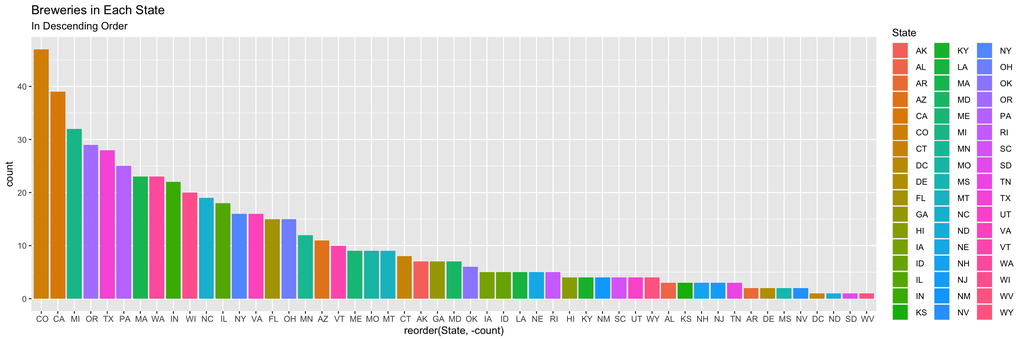

```r
#Plot in descending order by # of breweries per state
Breweries.By.State %>% ggplot(aes(x = reorder(State, -count) , y = count, fill = State)) + geom_bar(stat = "identity") + ggtitle("Breweries in Each State", "In Descending Order")
```

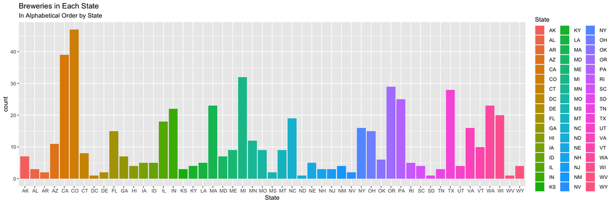

```r
#Plot in alphabetical order of States
ggplot(Breweries.By.State, mapping = aes(x = State, y = count, fill = State)) + geom_bar(stat = "identity") + ggtitle("Breweries in Each State", "In Alphabetical Order by State")
```

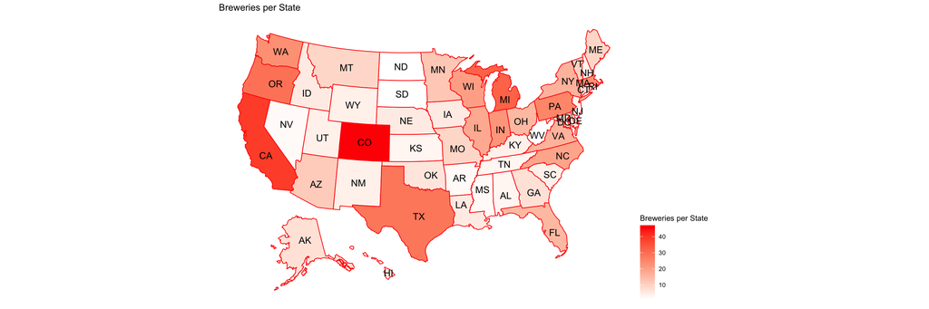

```r
#Create the US Map showing distribution of breweries
Breweries.By.State.Graph <- Breweries.By.State
Breweries.By.State.Graph$State <- trimws(Breweries.By.State.Graph$State)
colnames(Breweries.By.State.Graph)[colnames(Breweries.By.State.Graph) == "State"] <- "state"
plot_usmap(data = Breweries.By.State.Graph, values = "count", color = "red", labels=TRUE) +
  scale_fill_continuous(
    low = "white", high = "red", name = "Breweries per State", label = scales::comma
  ) + theme(legend.position = "right") +
  ggtitle("Breweries per State")
```

```r
#Pie Chart showing percentage of breweries held by top three states
Breweries.By.State.Graph
```

```
## # A tibble: 51 x 2
##    state count
##    <chr> <int>
##  1 CO       47
##  2 CA       39
##  3 MI       32
##  4 OR       29
##  5 TX       28
##  6 PA       25
##  7 MA       23
##  8 WA       23
##  9 IN       22
## 10 WI       20
## # … with 41 more rows
```

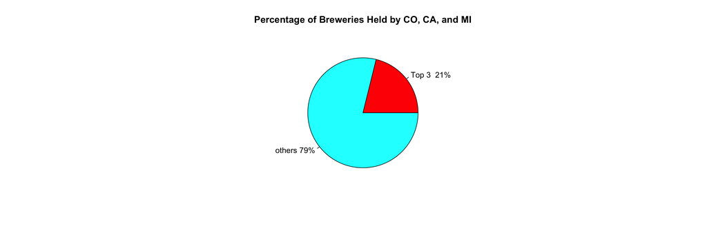

```r
top.3.States.Breweries <- sum(subset(Breweries.By.State.Graph,
                                     state == "CO" |
                                     state == "CA" |
                                     state == "MI" )$count)

other.Breweries <- sum(Breweries.By.State.Graph$count) - top.3.States.Breweries

slices <- c(top.3.States.Breweries, other.Breweries)
lbls <- c("Top 3 ", "others")
pct <- round(slices/sum(slices)*100)
lbls <- paste(lbls, pct) # add percents to labels
lbls <- paste(lbls,"%",sep="") # ad % to labels
pie(slices, labels = lbls, main="Percentage of Breweries Held by CO, CA, and MI", col=rainbow(length(lbls)))
```

## Question 2: Merge Data

Here, we merged the breweries dataset with the beers dataset and stored this in a new data frame called brewByState. We merged these datasets using brewery ID. Below, you can see the first and last six entries printed.

```r
#Merge Beers and Breweries datasets using Brewery ID
brewByState <- merge(Beers, Breweries, by.x=c("Brewery_id"),
                     by.y=c("Brew_ID"))
#Rename columns after merge
colnames(brewByState)[2] <- "BeerName"
colnames(brewByState)[8] <- "Brewery"
#Print first six entries in new data frame
brewByState[1:6,]
```

```
##   Brewery_id      BeerName Beer_ID   ABV IBU
## 1          1  Get Together    2692 0.045  50
## 2          1 Maggie's Leap    2691 0.049  26
## 3          1    Wall's End    2690 0.048  19
## 4          1       Pumpion    2689 0.060  38
## 5          1    Stronghold    2688 0.060  25
## 6          1   Parapet ESB    2687 0.056  47
##                                 Style Ounces            Brewery        City
## 1                        American IPA     16 NorthGate Brewing  Minneapolis
## 2                  Milk / Sweet Stout     16 NorthGate Brewing  Minneapolis
## 3                   English Brown Ale     16 NorthGate Brewing  Minneapolis
## 4                         Pumpkin Ale     16 NorthGate Brewing  Minneapolis
## 5                     American Porter     16 NorthGate Brewing  Minneapolis
## 6 Extra Special / Strong Bitter (ESB)     16 NorthGate Brewing  Minneapolis
##   State
## 1    MN
## 2    MN
## 3    MN
## 4    MN
## 5    MN
## 6    MN
```

```r
#Print the last six entries in new data frame
last = nrow(brewByState)
prev = last - 5
brewByState[prev:last,]
```

```
##      Brewery_id                  BeerName Beer_ID   ABV IBU
## 2405        556             Pilsner Ukiah      98 0.055  NA
## 2406        557  Heinnieweisse Weissebier      52 0.049  NA
## 2407        557           Snapperhead IPA      51 0.068  NA
## 2408        557         Moo Thunder Stout      50 0.049  NA
## 2409        557         Porkslap Pale Ale      49 0.043  NA
## 2410        558 Urban Wilderness Pale Ale      30 0.049  NA
##                        Style Ounces                       Brewery          City
## 2405         German Pilsener     12         Ukiah Brewing Company         Ukiah
## 2406              Hefeweizen     12       Butternuts Beer and Ale Garrattsville
## 2407            American IPA     12       Butternuts Beer and Ale Garrattsville
## 2408      Milk / Sweet Stout     12       Butternuts Beer and Ale Garrattsville
## 2409 American Pale Ale (APA)     12       Butternuts Beer and Ale Garrattsville
## 2410        English Pale Ale     12 Sleeping Lady Brewing Company     Anchorage
##      State
## 2405    CA
## 2406    NY
## 2407    NY
## 2408    NY
## 2409    NY
## 2410    AK
```